# Problema 1: Estimación de la probabilidad y la media

Simulación, Estimación e Inferencia Estadística · 2026-A

Integrantes: Juan Alejandro Carrillo Jaimes & David Burgoa

2026-03-22

# 1 Descripción del Problema

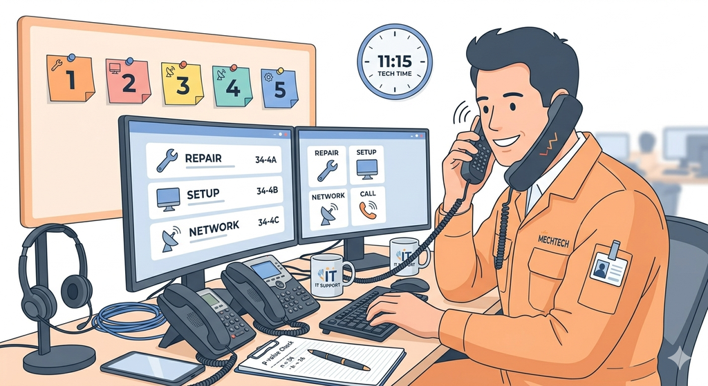

Figure 1.1: Empresa de servicio técnico

Una empresa de servicio técnico recibe, en promedio, **5** solicitudes de reparación por hora. Suponiendo que el número de solicitudes sigue una distribución de Poisson, realizar las siguientes actividades

# 2 .Cálculo de probabilidad teórica

Calcular P(X = 3), es decir, la probabilidad de que lleguen exactamente 3 solicitudes en una hora según la distribución de Poisson.

La probabilidad de que lleguen exactamente $X = 3$ solicitudes en una hora se calcula con la fórmula de Poisson:

$$P(X = 3) = \frac{e^{-\lambda} \cdot \lambda^X}{X!} =
\frac{e^{-5} \cdot 5^3}{3!} = \frac{0.006738 \cdot 125}{6} = 0.1404$$

```r
lambda <- 5
p_teorica <- dpois(3, lambda = lambda)
print(paste("La probabilidad teorica es:", round(p_teorica,4)))
```

```
## [1] "La probabilidad teorica es: 0.1404"
```

# 3 .Simulación con una muestra

- Genera la muestra: X ~ Poisson(λ=5), n = 1.000
- Calculá la frecuencia relativa X=3 (fn(X=3)).
- Compara la probabilidad teórica P(X=3) e interpreta la aproximación.

```r
set.seed(1005062032) # Codigo: Est Juan Alejandro Carrillo Jaimes

muestra <- rpois(1000, lambda = lambda)

freq_rel <- mean(muestra == 3)

print(paste("La probabilidad relativa es:", round(freq_rel,5)))
```

```
## [1] "La probabilidad relativa es: 0.134"
```

## 3.1 .Compracion:

```r
tabla <- data.frame(
  N = 1:2,
  Medida = c("Probabilidad Teórica", "Frecuencia Relativa"),
  Valor  = c(p_teorica, freq_rel)
)

tabla %>%
  gt() %>%
  fmt_number(
    columns = Valor,
    decimals = 4
  ) %>%
  cols_label(
    N = "N°",
    Medida = "Indicador",
    Valor = "Resultado"
  ) %>%
  tab_header(
    title = md("**Tabla 1. Comparación entre probabilidad teórica y frecuencia relativa**"),
    subtitle = "Distribución Poisson con λ = 5"
  ) %>%
  cols_align(
    align = "center",
    columns = c(N, Valor)
  ) %>%
  tab_options(
    table.font.size = 14,
    heading.title.font.size = 16,
    heading.subtitle.font.size = 13
  )
```

**Tabla 1. Comparación entre probabilidad teórica y frecuencia relativa**

Distribución Poisson con λ = 5

| N° | Indicador | Resultado |
| --- | --- | --- |
| 1 | Probabilidad Teórica | 0.1404 |
| 2 | Frecuencia Relativa | 0.1340 |

**Observacion:**

- La pequeña diferencia entre ambas se debe a la variabilidad muestral, y es probable que disminuya al aumentar el tamaño de la muestra (Ver tabla 1).

# 4 .Análisis de la variabilidad entre muestras

- Genera 100 muestras aleatorias de tamaño n=1,000.
- Calcula la frecuencia relativa para X=3 en cada muestra.

Construye un gráfico de dispersión:

- Eje X : Indexación por cada muestra (1 a 100).
- Eje Y : Frecuencias relativas fn(X=3).

Dibuja una línea horizontal en P(X=3) y comenta si existe una tendencia.

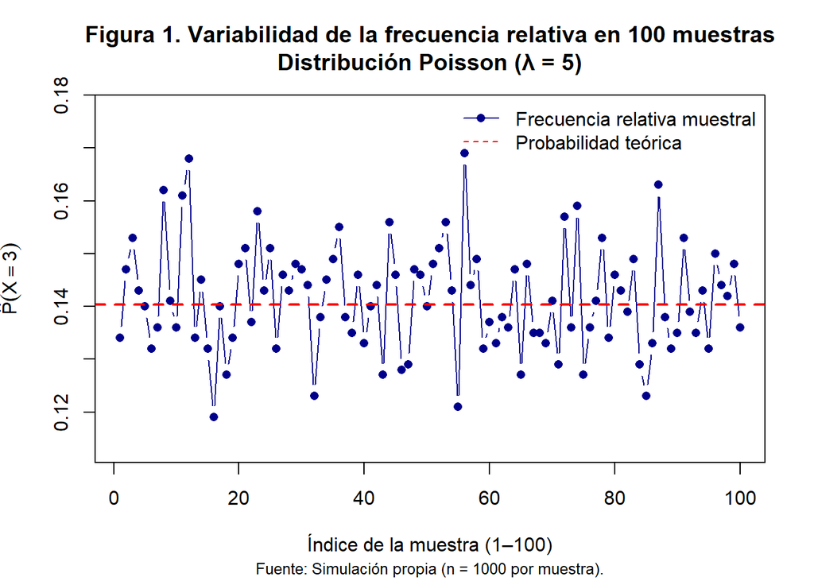

Figure 4.1: Variabilidad de la frecuencia relativa en 100 muestras — Poisson(λ=5)

```r
set.seed(1005062032) # Codigo: Est Juan Alejandro Carrillo Jaimes

frecuencias <- numeric(100)

for(i in 1:100){
  m <- rpois(1000, lambda)
  frecuencias[i] <- mean(m == 3)
}

plot(frecuencias,
     type = "b",
     pch = 16,
     col = "darkblue",
     xlab = "Índice de la muestra (1–100)",
     ylab = expression(hat(P)(X==3)),
     main = "Figura 1. Variabilidad de la frecuencia relativa en 100 muestras\nDistribución Poisson (λ = 5)",
     ylim = c(min(frecuencias)*0.95, max(frecuencias)*1.05))

abline(h = p_teorica,
       col = "red",
       lwd = 2,
       lty = 2)

legend("topright",
       legend = c("Frecuencia relativa muestral",
                  "Probabilidad teórica"),
       col = c("darkblue", "red"),
       lty = c(1, 2),
       pch = c(16, NA),
       bty = "n")

mtext("Fuente: Simulación propia (n = 1000 por muestra).",
      side = 1,
      line = 4,
      cex = 0.8)
```

La Figura 4.1 muestra que las 100 frecuencias relativas oscilan entre aproximadamente $0.12$ y $0.17$, con un promedio de 0.1414, muy cercano a $P(X=3) = 0.1404$. Esto evidencia que no existe una tendencia sistemática — las estimaciones fluctúan aleatoriamente alrededor del valor teórico, confirmando la consistencia del estimador.

**Observacion:**

# 5 .Impacto del tamaño muestral

- Genera muestras aleatorias con tamaños: 5, 10, 20, 30, 40, 50, 60, 70, 80, 90, 100, 200, 300, 400, 500, 600, 700, 800, 900 y 1,000. Agrega valores si consideras que mejora el análisis de los resultados.
- Calcula la frecuencia relativa de X=3 para cada tamaño.

Construye un gráfico de dispersión:

- Eje X : Indexación (1 al 20) por cada tamaño muestral.
- Eje Y : Frecuencias relativas fn(X=3).

Dibuja la línea en P(X=3) y describe si aparece una tendencia.

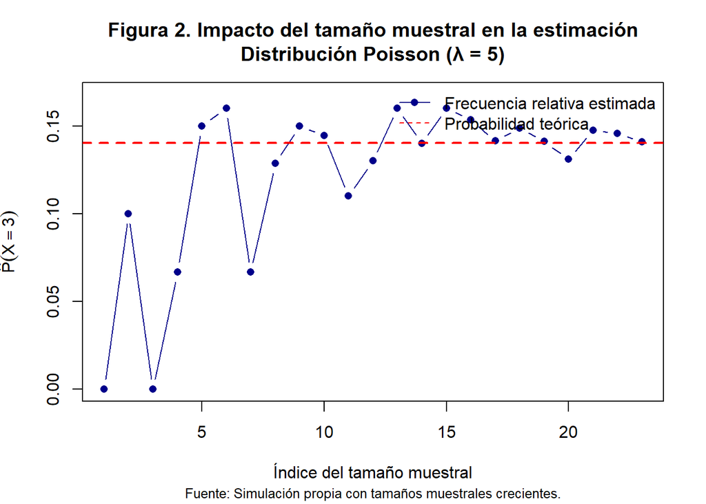

Figure 5.1: Impacto del tamaño muestral en la estimación — Poisson(λ=5)

```r
sizes <- c(5,10,20,30,40,50,60,70,80,90,
           100,200,300,400,500,600,700,800,900,1000, 2000, 3000, 1000000)

frecuencias_size <- numeric(length(sizes))

set.seed(1005062032) # Codigo: Est Juan Alejandro Carrillo Jaimes

for(i in 1:length(sizes)){
  m <- rpois(sizes[i], lambda)
  frecuencias_size[i] <- mean(m == 3)
}

plot(frecuencias_size,
     type = "b",
     pch = 16,
     col = "darkblue",
     xlab = "Índice del tamaño muestral",
     ylab = expression(hat(P)(X==3)),
     main = "Figura 2. Impacto del tamaño muestral en la estimación\nDistribución Poisson (λ = 5)",
     ylim = c(min(frecuencias_size)*0.95,
              max(frecuencias_size)*1.05))

abline(h = p_teorica,
       col = "red",
       lwd = 2,
       lty = 2)

legend("topright",
       legend = c("Frecuencia relativa estimada",
                  "Probabilidad teórica"),
       col = c("darkblue", "red"),
       lty = c(1, 2),
       pch = c(16, NA),
       bty = "n")

mtext("Fuente: Simulación propia con tamaños muestrales crecientes.",
      side = 1,
      line = 4,
      cex = 0.8)
```

**observaciones:**

- Se incorporaron tres tamaños muestrales adicionales (2000, 3000 y 1,000,000) con el objetivo de evidenciar con mayor claridad el efecto de la Ley de los Grandes Números. Como se observa en la Figura 2, a medida que el tamaño muestral aumenta, la estimación se aproxima progresivamente a la probabilidad teórica; en particular, para n=1,000,000 , la diferencia es prácticamente imperceptible, mostrando una convergencia casi exacta hacia el valor esperado (ver Figura 2).

# 6 .Convergencia de la media muestral

- Genera 100 muestras de tamaño n=1,000.
- Calcula el promedio muestral de solicitudes en cada muestra.

Construye un gráfico de dispersión:

- Eje X : Indexación por cada muestra (1 a 100).
- Eje Y : Promedios muestrales.
- Traza la línea horizontal en la media teórica (λ) y analiza la tendencia.

Para una distribución Poisson con parámetro $\lambda$, la media y varianza poblacionales son iguales:

$$E[X] = \lambda = 5 \qquad Var[X] = \lambda = 5$$

Por tanto, el estimador $\bar{X}$ debe converger a $\lambda = 5$ conforme aumenta $n$, por la Ley de los Grandes Números.

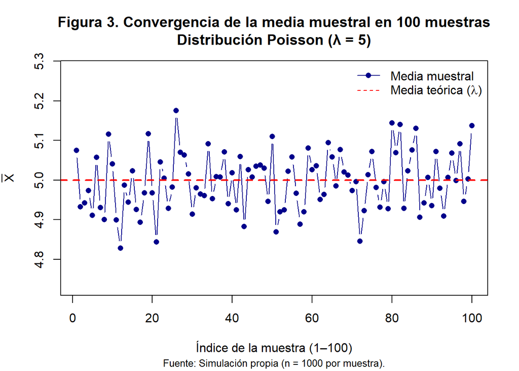

Figure 6.1: Convergencia de la media muestral en 100 muestras — Poisson(λ=5)

```r
set.seed(1005062032) # Codigo: Est Juan Alejandro Carrillo Jaimes

medias <- numeric(100)

for(i in 1:100){
  m <- rpois(1000, lambda)
  medias[i] <- mean(m)
}

plot(medias,
     type = "b",
     pch = 16,
     col = "darkblue",
     xlab = "Índice de la muestra (1–100)",
     ylab = expression(bar(X)),
     main = "Figura 3. Convergencia de la media muestral en 100 muestras\nDistribución Poisson (λ = 5)",
     ylim = c(min(medias)*0.98, max(medias)*1.02))

abline(h = lambda,
       col = "red",
       lwd = 2,
       lty = 2)

legend("topright",
       legend = c("Media muestral",
                  expression(paste("Media teórica (", lambda, ")"))),
       col = c("darkblue", "red"),
       lty = c(1, 2),
       pch = c(16, NA),
       bty = "n")

mtext("Fuente: Simulación propia (n = 1000 por muestra).",
      side = 1,
      line = 4,
      cex = 0.8)
```

**observaciones:**

- La Figura 3 muestra que las medias muestrales obtenidas en las 100 simulaciones se distribuyen alrededor del valor teórico λ=5. Aunque existe variabilidad entre muestras, las estimaciones se mantienen cercanas al valor esperado, evidenciando estabilidad y coherencia con las propiedades teóricas de la distribución de Poisson.

# 7 .Impacto del tamaño muestral en la media

- Genera muestras aleatorias con tamaños: 5, 10, 20, 30, 40, 50, 60, 70, 80, 90, 100, 200, 300, 400, 500, 600, 700, 800, 900 y 1,000. Agrega valores si consideras que mejora el análisis de los resultados.
- Calcula el promedio muestral para cada tamaño.

Construye un gráfico de dispersión:

- Eje X : Indexación (1 al 20) por cada tamaño muestral.
- Eje Y : Promedios muestrales.
- Dibuja la línea horizontal en la media teórica (λ) y compara si el promedio se aproxima a medida que crece el tamaño.

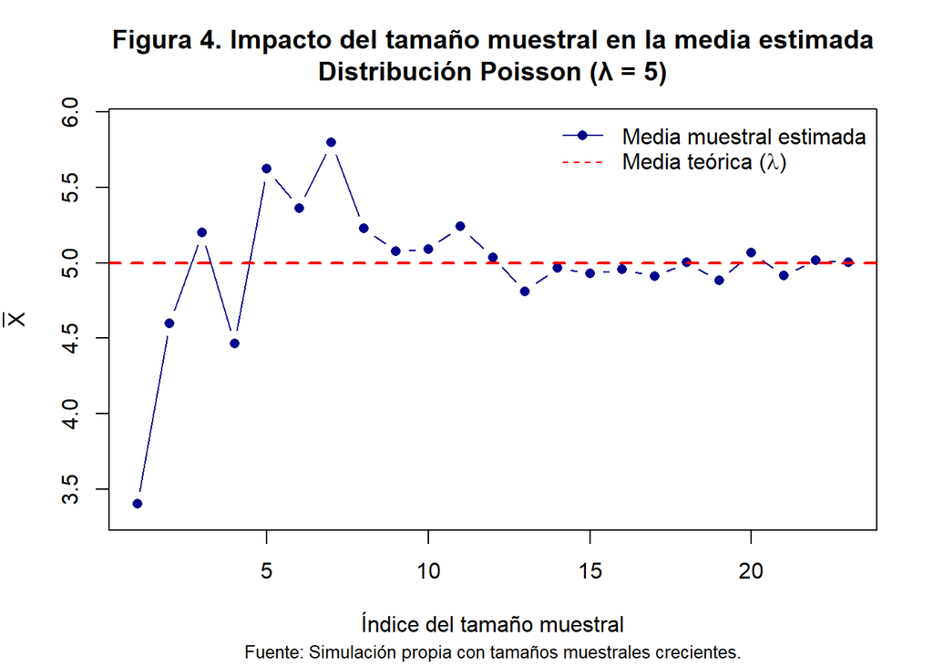

Figure 7.1: Impacto del tamaño muestral en la media estimada — Poisson(λ=5)

```r
medias_size <- numeric(length(sizes))

set.seed(1005062032) # Codigo: Est Juan Alejandro Carrillo Jaimes

for(i in 1:length(sizes)){
  m <- rpois(sizes[i], lambda)
  medias_size[i] <- mean(m)
}

plot(medias_size,
     type = "b",
     pch = 16,
     col = "darkblue",
     xlab = "Índice del tamaño muestral",
     ylab = expression(bar(X)),
     main = "Figura 4. Impacto del tamaño muestral en la media estimada\nDistribución Poisson (λ = 5)",
     ylim = c(min(medias_size)*0.98,
              max(medias_size)*1.02))

abline(h = lambda,
       col = "red",
       lwd = 2,
       lty = 2)

legend("topright",
       legend = c("Media muestral estimada",
                  expression(paste("Media teórica (", lambda, ")"))),
       col = c("darkblue", "red"),
       lty = c(1, 2),
       pch = c(16, NA),
       bty = "n")

mtext("Fuente: Simulación propia con tamaños muestrales crecientes.",
      side = 1,
      line = 4,
      cex = 0.8)
```

**Observacion:**

- La Figura 4 evidencia que, para tamaños muestrales pequeños, la media estimada presenta mayor variabilidad respecto al valor teórico λ=5. Sin embargo, conforme el tamaño muestral aumenta, la estimación se estabiliza y converge progresivamente hacia la media poblacional, mostrando el efecto de la Ley de los Grandes Números.